# 06-Taxonomy

# Taxonomic Name Resolution when Importing Data in to BETY

## Name Resolution

When users have plant trait data that they want to enter in to the database, the data needs to attributed to a specific species database record. When the user has no other information (such as ID codes like the USDA and FIA codes) the only way to match the species in the data with species entry in the database is through matching of scientific names.

But it may be the case that the accepted scientific name has changed since the data was collected (and/or published), or that the data itself contains errors (typos or otherwise) such that the names in the data are not matching with anything that has already been entered in to BETY. It is also the case that BETY does not have a complete record.

At this point we need to employ additional tools to help us in resolving taxonomic names. Already in the PEcAn code there exists

- [`match_species_id`](https://github.com/PecanProject/pecan/blob/develop/modules/data.land/R/match_species_id.R): But this cannot account for fuzzy matching of names (ie spelling errors) and synonyms.
- [`94.match.species`](https://github.com/PecanProject/pecan/blob/297087787cfec6129428e1e334297ed2b6030a06/base/db/inst/import-try/94.match.species.R): This code is specific to importing data from thr TRY database and experiments with some partial matching through grep statements, but again does not account for synonyms.

Outside of PEcAn, there is the [Taxonomic Name Resolution Service](http://tnrs.iplantcollaborative.org/TNRSapp.html)

Additionally, there is an R package [taxize](https://ropensci.github.io/taxize-book/) which, among other things, provides an R interface between TNRS and R.

I recommend checking out their [vignettes](https://cran.r-project.org/web/packages/taxize/vignettes/) - you can also just access them on their [github](https://github.com/ropensci/taxize).

## Building a Tropical PFT

My goal is not only to import trait data, but to build a PFT that I can used to do runs in the tropics. **(How general should this PFT be? That’s a good question!)**

Right now I’m using a clone of the tropical PFT that was made to be used with FATES. Thus it contains all the imported BETY entries from the ForestGEO Neotropical tree database (http://ctfs.si.edu/webatlas/neotropicaltree/) and more. There are currently 22286 species linked to the PFT, 20811 of which are the ForestGEO entries.

If I’m importing data with species that are not in the existing PFT, I need to decide if they should be added. And I suppose I should also make sure there aren’t any species in the PFT that shouldn’t be there. This is something that I have no expertise in so I would like advice. Below I’m loading in all the spcies names from my PFT (id = 1000000131)

```r
pftid <- 1000000131
PFT_species <- tbl(bety, "pfts") %>% dplyr::rename(pft_id = id) %>% filter(pft_id == pftid) %>%
  inner_join(., tbl(bety, "pfts_species"), by = "pft_id") %>%
  inner_join(., tbl(bety, "species") %>% dplyr::rename(specie_id = id), by = "specie_id") %>%
  dplyr::select(one_of("pft_id", "name", "specie_id", "genus", "species", "scientificname", "notes")) %>%
  collect()

# Check that all the ForestGEO species are in the PFT (they are)
nForestGEO <- tbl(bety, "species") %>% filter(str_detect(notes, "ForestGEO")) %>% collect() %>% nrow()
PFT_species %>% filter(str_detect(PFT_species$notes, "ForestGEO")) %>% nrow() == nForestGEO

PFT_species$notes <- NULL
```

## What I need help with

I need to import trait data in to the database and I need to match the species names in the data to the records in BETY. Furthermore, I need to decide if I need to add records or change existing records in BETY.

I’ll refer to the species name in the data set as “submitted name” - I run these names through the TNRS to see if returns spelling corrections or a different “accepted name.”

For example:

If my submitted name is `"Simaroubu glauca"` (which I misspelled from Simarouba glauca)

```r
submit_name <- "Simaroubu glauca"
tnrs(query = submit_name)
```

[output not shown]

When I use the name resolving tools, and try to match the submitted and accepted names to BETY I come up with 13 different cases that can potentially arrise. I’ll go through each one in detail below:

```r
#------------------------------------------------------------------------------#
# Both the submitted and accepted names in BETY

# Check if they equal each other
submit_accept <- sp$submit_bety_id[i] == sp$accept_bety_id[i]

# They equal each other
case01 <- submit_bety & accept_bety & submit_accept & accept_PFT # Best case, don't need to do anything.
case02 <- submit_bety & accept_bety & submit_accept & !accept_PFT

# They don't equal one another
case03 <- submit_bety & accept_bety & !submit_accept & submit_PFT & accept_PFT
case04 <- submit_bety & accept_bety & !submit_accept & submit_PFT & !accept_PFT
case05 <- submit_bety & accept_bety & !submit_accept & !submit_PFT & accept_PFT
case06 <- submit_bety & accept_bety & !submit_accept & !submit_PFT & !accept_PFT

#------------------------------------------------------------------------------#
# Only one name in BETY

# Submitted name not in bety, accepted name in BETY
case07 <- !submit_bety & accept_bety & accept_PFT
case08 <- !submit_bety & accept_bety & !accept_PFT

# Submitted name in bety, accepted name not in BETY
case09 <- submit_bety & submit_PFT & !accept_bety
case10 <- submit_bety & !submit_PFT & !accept_bety

#------------------------------------------------------------------------------#
# None of the names are in BETY
case11 <- !submit_bety & !accept_bety & toupper(sp$submit_name[i]) == toupper(sp$accept_name[i])
case12 <- !submit_bety & !accept_bety & toupper(sp$submit_name[i]) != toupper(sp$accept_name[i])

#------------------------------------------------------------------------------#
# Special unlucky number 13 case that the TNRS could not find an accepted name.
# Or TNRS returned a blank which is super lame and confusing.
# These will need to be resolved by hand.
case13 <- !accept_name_exists
if(case13){
  case01 = case02 = case03 = case04 = case05 = case06 = case07 = case08 =
    case09 = case10 = case11 = case12 = FALSE
}
```

Using a list of 131 species from trait data that I need to import in to BETY (from various sources), I determined the case for each name in a separate script. The result of this analysis are in the file `/fs/data3/ecowdery/ED.Hydro/parameters/constraint_calculations/constraint_data/species_out.csv`.

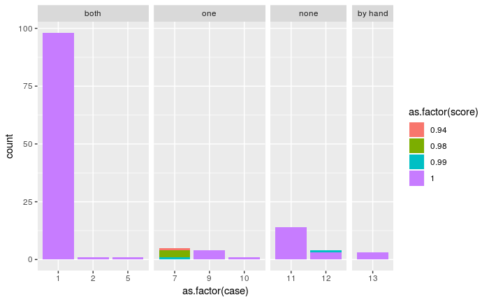

```r
species_out = read.csv(file = "/fs/data3/ecowdery/ED.Hydro/parameters/constraint_calculations/constraint_data/species_out.csv",
                       stringsAsFactors = FALSE) %>%
  select(-one_of(c("X", "X.1")))

species_out <- species_out %>%
  mutate(category = case_when(case <= 6 ~ "both",
                              6 < case & case <= 10 ~ "one",
                              10 < case & case <= 12 ~ "none",
                              case == 13 ~ "by hand"))
species_out$category <- factor(species_out$category, levels = c("both", "one", "none", "by hand"))

# Here I color the entries by "score" which is just how "close" the match is
# So the score would go down for a spelling error for example
ggplot(data = species_out) +
  geom_bar(aes(x = as.factor(case), fill = as.factor(score))) +
  facet_grid(aes(cols = category), scales = "free", space = "free")
```

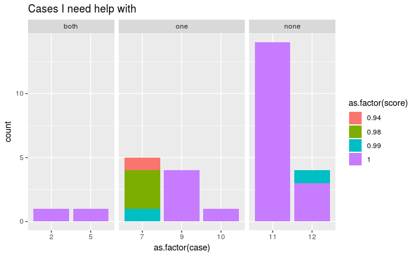

```r
# Special case for which the TNRS did not work, I'll get to this later
species_special <- species_out %>% filter(case == 13)

# Entries for which the TNRS did work
species_case <- species_out %>% filter(case != 13)
# dim(species_case)

ggplot(data = species_case %>% filter(case != 1)) +
  geom_bar(aes(x = as.factor(case), fill = as.factor(score))) +
  ggtitle("Cases I need help with") +
  facet_grid(aes(cols = category), scales = "free", space = "free")
```

Luckily, case 1, the one in which the submitted name and accepted name agree and are in BETY and in the tropical PFT is the predominant case. However, there are a lot of other cases that need sorting through. This is where I need help!

**Specific places I would love opinions: case 3-6 & 9-10**

## Cases

### Both the submitted and accepted names in BETY and they are the same

#### Case 1

- Submit name **is** in BETY
- Accept name **is** in BETY
- Submit name = Accept name
- Submit name **is** in PFT
- Accept name **is** in PFT

This is the best case, we don’t need to do anything!

```r
my_table(species_case, 1) %>% scroll_box(height = "200px")
```

[output not shown]

#### Case 2

- Submit name **is** in BETY
- Accept name **is** in BETY
- Submit name = Accept name
- Submit name **is not** in PFT
- Accept name **is not** in PFT

This seems pretty straightforward. We don’t need to add anything to the species table. Do we add the name to the PFT?

### Both the submitted and accepted names in BETY and they are NOT the same

- This is complicated!
- If the submitted names in BETY are out of date, should they be replaced by the new accepted names?
- If we keep the submitted name species record in BETY
- How does this decision affect trait records linked to that species record?
- How does this decision affect whether or not the submitted name stays in the PFT?
- Should the trait data that hasn’t been entered yet be linked to the submitted name species record or the accepted name species record?

Keep these questions in mind when looking through not only cases 3-6 but also 9-10

#### Case 3

- Submit name **is** in BETY
- Accept name **is** in BETY
- Submit name != Accept name
- Submit name **is** in PFT
- Accept name **is** in PFT

#### Case 4

- Submit name **is** in BETY
- Accept name **is** in BETY
- Submit name != Accept name
- Submit name **is** in PFT
- Accept name **is not** in PFT

#### Case 5

- Submit name **is** in BETY
- Accept name **is** in BETY
- Submit name != Accept name
- Submit name **is not** in PFT
- Accept name **is** in PFT

[output not shown]

#### Case 6

- Submit name **is** in BETY
- Accept name **is** in BETY
- Submit name != Accept name
- Submit name **is not** in PFT
- Accept name **is not** in PFT

### Only the accepted name is in in BETY

Here there aren’t too many questions, as long as we are ok with entering the trait data under the accepted name (and potentially adding the accepted name to the PFT.)

#### Case 7

This is where a lot of the spelling errors live.

- Submitted name **is not** in BETY
- Accepted name **is** in BETY
- Accepted name **is** in PFT

#### Case 8

- Submitted name **is not** in BETY
- Accepted name **is** in BETY
- Accepteed name **is not** in PFT

### Only the submitted name is in in BETY

Decisions about how to handle cases 9 and 10 depend on how we choose to handle cases 3-6.

#### Case 9

- Submitted name **is** in BETY
- Submitted name **is** in PFT
- Accepted name **is not** in BETY

Questions:

- Should I add the new accepted names to the database? Should the trait data that I haven’t entered yet be entered under the submitted names or the accepted names?

#### Case 10

- Submitted name **is** in BETY
- Submitted name **is not** in PFT
- Accepted name **is not** in BETY

Questions:

- See all the questions associated with case 9.
- The answers to case 9 questions affects whether or not the submitted names in case 10 should be added to the PFT.

### None of the names are in BETY

#### Case 11

Submitted and Accepted name is the same and is not in BETY - do we add it?

#### Case 12

Submitted and Accepted names are not the same and are not in BETY - which do we add? (See case 3-6,9-10)

### TNRS didn’t work

#### Case 13

These I’m going to need to go through by hand to figure out why the queries didn’t work.

| submit_name | submit_bety_id | submit_in_PFT | accept_name | accept_bety_id | accept_in_PFT | uri |
| --- | --- | --- | --- | --- | --- | --- |
| BYRSONIMA CRASSA | NA | FALSE | NA | NA | FALSE | NA |
| SYMPLOCOS MOSENII | NA | FALSE |  | NA | FALSE |  |
| TACHIGALIA VERSICOLOR | NA | FALSE |  | NA | FALSE |  |